# YVR Energy Consumption Forecasting

### Names of students:

Allen Yu

Qianyun Sang

Project description  
Part A: Time plot, trying transformations/adjustments, creating training and test set  
Part B  
Introduction & Approach  
Exploratory Data Analysis  
Potential causes of patterns  
Exponential Smoothing Model  
ARIMA model  
Comparison of models  
Forecasts  
Discussion

Appendix A: ETS Models  
Appendix B: ARIMA Models

# Project description

**Objective**

The main goal of this project is to develop a model to forecast monthly energy use for the Vancouver International Airport (YVR).

**Introduction**

Budget planning at YVR requires forecasting the cost of energy to operate the airport. An accurate forecast could help the YVR representatives negotiate more favourable contracts with energy suppliers.

**Data Available**

Data was taken from 14 years of records from the YVR database. This data set includes information on date, energy use, temperature, terminal area, and number of passengers. Data have been aggregated by month into 168 records (14 years with 12 months each).

| # | Variable | Definition |
| --- | --- | --- |
| 1 | month | Month and year, e.g.: Nov-98 |
| 2 | energy | Energy use measured in thousands of kilowatt hours (kWh) |
| 3 | mean.temp | Mean monthly temperature outside (degrees Celsius) |
| 4 | total.area | Total area of all terminals (sq. m.) |
| 5 | total.passengers | Total number of passengers in thousands |
| 6 | domestic.passengers | Total number of domestic passengers (traveling within Canada) in thousands |
| 7 | US.passengers | Total number of passengers traveling between Canada and the US in thousands |
| 8 | international.passengers | Total number of passengers traveling between YVR and countries other than Canada/US |

In this project, you will develop appropriate models, compare the models, and discuss advantages and limitations of each model. You should select the best model and use it to provide monthly forecasts for energy use for the next three years (January 2011 through December 2013).

# Part A (3.5 marks)

## Time plot, trying transformations/adjustments, creating training and test set

### See Canvas submission called "Project: Part A" for detailed questions and points breakdown.

### Import the data

Create a time series object of the energy use. See the steps on Canvas if you aren't sure how to create a time series object in R.

```r
# Load required libraries
library(tseries)
library(forecast)
library(ggplot2)

data <- read.csv("Energy use at YVR.csv")
```

### Time plot (0.5 marks)

Create a time plot of the electricity use data. Prepare this plot as if for publication and upload the image to Canvas. You do not have to describe the plot.

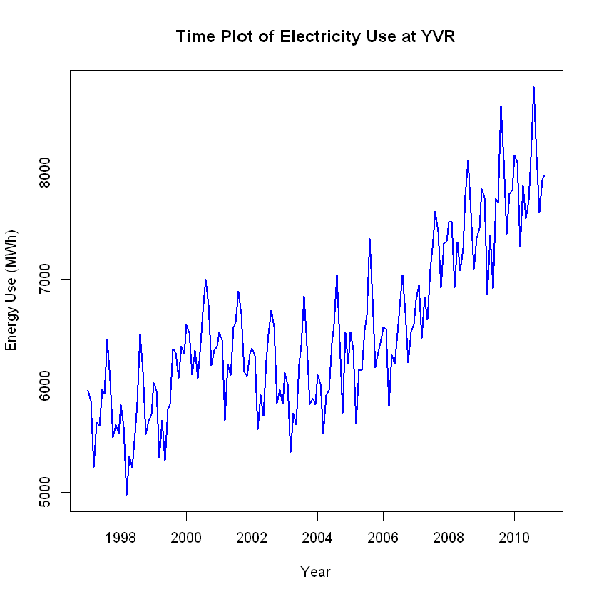

```r
# Convert 'month' column to Date format
data$month <- as.Date(paste0("01-", data$month), format="%d-%b-%y")

ts_energy <- ts(data$energy, start=c(1997,1), frequency=12)

# Time plot
plot(ts_energy, main="Time Plot of Electricity Use at YVR", xlab="Year", ylab="Energy Use (MWh)", col="blue", lwd=2)
```

### Box-Cox transformation (1 mark)

Write the code to do a Box-Cox transformation of the electricity use data (this will be submitted as part of the last question for Part A of the project).

Create a time plot of the transformed data. Prepare this plot as if for publication and upload the image.

Explain the purpose of using the Box-Cox transformation and if it was effective for this dataset (5 sentences max).

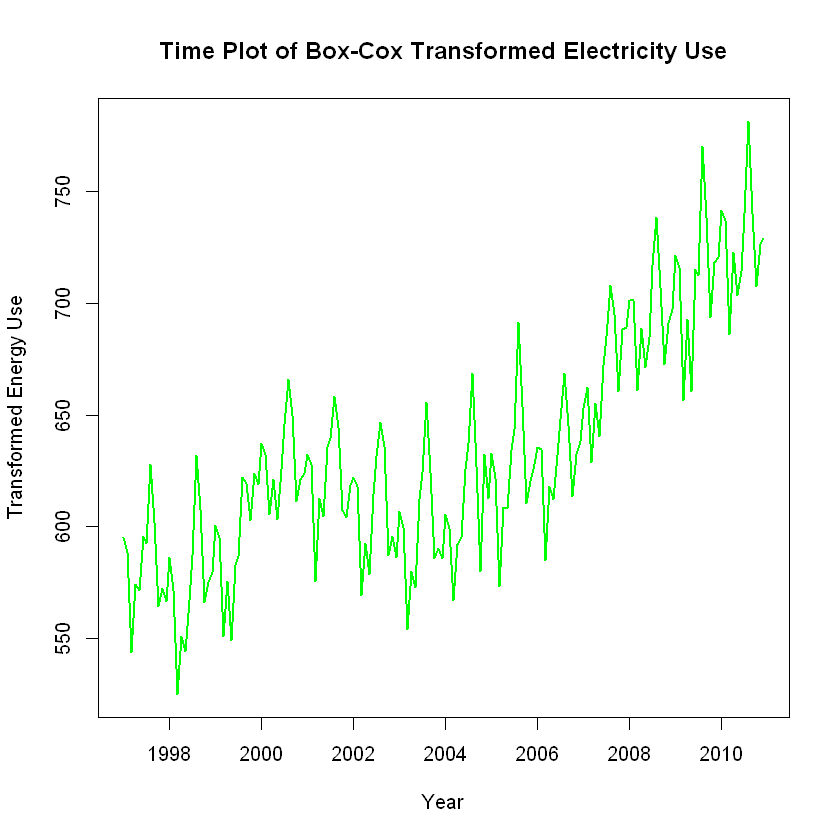

```r
# Box-Cox transformation
lambda_bc <- BoxCox.lambda(ts_energy)
ts_energy_bc <- BoxCox(ts_energy, lambda_bc)

# Time plot of transformed data
plot(ts_energy_bc, main="Time Plot of Box-Cox Transformed Electricity Use", xlab="Year", ylab="Transformed Energy Use", col="green", lwd=2)
```

### Calendar adjustment for number of days in each month (1 mark)

Write the code to do a calendar adjustment based on number of days in each month for the electricity use data - use the original data, not the transformed data (this code will be submitted as part of the last question for Part A of the project).

Create a time plot of the calendar adjusted data. Prepare this plot as if for publication and upload the image.

Explain the purpose of using this calendar adjustment and if it was effective for this dataset (5 sentences max).

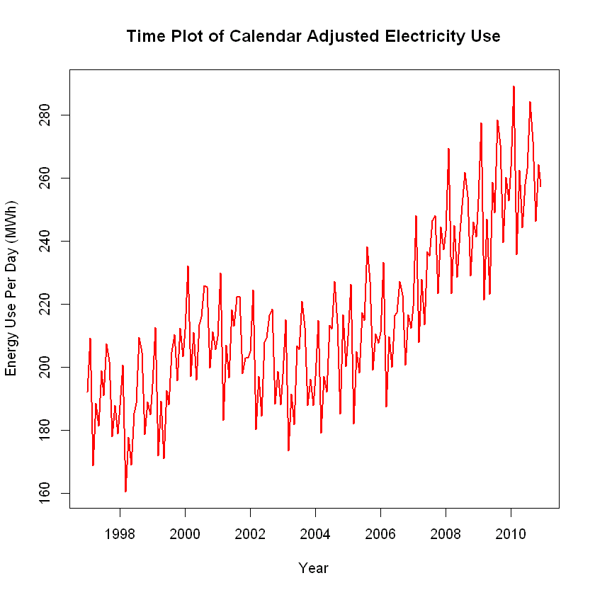

```r
# Calendar adjustment
days_in_month <- c(31, 28, 31, 30, 31, 30, 31, 31, 30, 31, 30, 31)
data$days_in_month <- rep(days_in_month, length.out=nrow(data))
data$energy_adjusted <- data$energy / data$days_in_month
ts_energy_adjusted <- ts(data$energy_adjusted, start=c(1997,1), frequency=12)

# Time plot of calendar-adjusted data
plot(ts_energy_adjusted, main="Time Plot of Calendar Adjusted Electricity Use", xlab="Year", ylab="Energy Use Per Day (MWh)", col="red", lwd=2)
```

# Explanation of purpose of calendar adjustment:

- The purpose of the calendar adjustment is to account for the varying number of days in each month, which affects monthly electricity consumption.
- By dividing the monthly energy use by the number of days in the month, the adjustment calculates daily energy usage to provide a consistent basis for comparison across months.
- The original time plot shows fluctuations partly due to different month lengths, which could obscure actual trends in energy consumption.
- The adjusted plot shows more stable and comparable energy use per day, eliminating the bias caused by uneven month durations.
- This adjustment is effective for this dataset, as it reduces misleading variability, making underlying patterns in energy consumption clearer for modeling and forecasting.

Is there a different calendar-related adjustment that you think would be more effective? Describe it and why you think it could be more effective (5 sentences max). Note: you do not have to write code or perform this adjustment. (0.5 marks)

# Different calendar-related adjustment might be more effective

A potential alternative calendar-related adjustment is to adjust for seasonal and holiday effects, such as significant reductions or spikes in energy usage during holidays (e.g., Christmas, New Year) and peak travel periods. This adjustment would involve creating dummy variables or factors that account for these events and incorporating them into the forecasting model. It could be more effective because holidays and seasonal events likely contribute to large variations in energy consumption, especially in an airport setting with fluctuating passenger volumes. By addressing both month length and event-driven demand changes, the model would have a more robust understanding of consumption patterns. This could enhance forecasting accuracy by reducing unexplained variations not captured by the standard daily adjustment.

### Divide the data into the training set and the test set (0.25 marks)

Write the code to create the training set and the test set. Show the code as your answer on Canvas.

```r
# Split data into training and test sets
train_size <- round(length(ts_energy) * 0.8)
train_set <- window(ts_energy, end=c(1997 + (train_size - 1) %/% 12, (train_size - 1) %% 12 + 1))
test_set <- window(ts_energy, start=c(1997 + (train_size - 1) %/% 12, (train_size - 1) %% 12 + 2))

print(length(train_set))
print(length(test_set))
```

```
[1] 134
[1] 34
```

Upload your code to Canvas for Part A (0.25 marks)

# Part B

### Note that Part B includes everything below this header

### Make sure that your code is organized and includes useful annotations and written descriptions of what you are seeing on plots or the conclusions that you are drawing. (0.5 marks)

### Prepare all plots for publication by including detailed axis labels.

### Complete anwers will include observations and conclusions/interpretations.

# Exploratory Data Analysis (300 words max.) (4 marks)

Create plots of the electricity use data (**use all the data, not just the training set**); prepare them as if for publication and upload them. Include a decomposition plot from STL decomposition.

Describe the characteristics of trend, cycle and seasonality in detail, referring to specific characteristics of the plots. Also mention any unusual features, if present. Be specific.

Organize your answers as follows:

Seasonality: ...

Trend/cycle: ...

Unusual features: ...

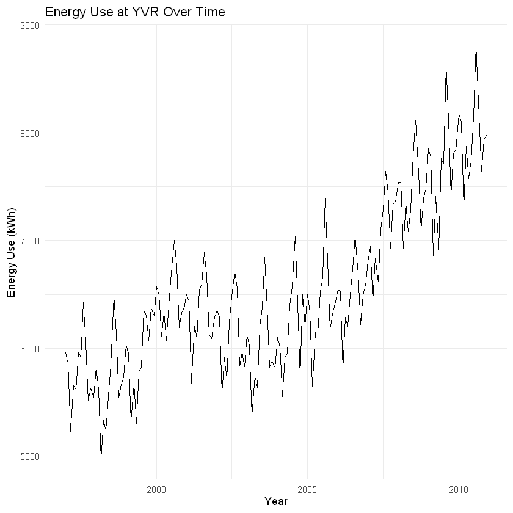

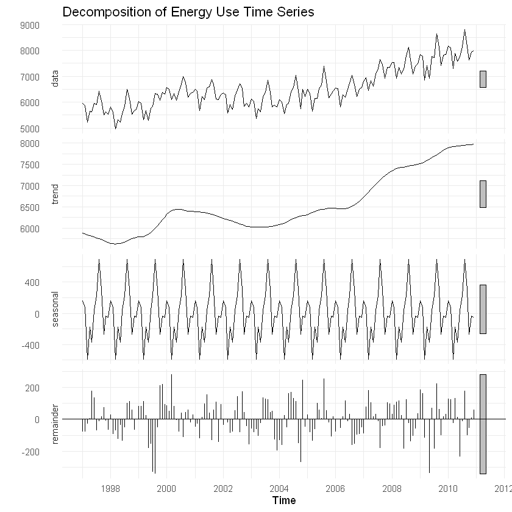

```r
# Plot time series
autoplot(ts_energy) +
  ggtitle("Energy Use at YVR Over Time") +
  xlab("Year") +
  ylab("Energy Use (kWh)") +
  theme_minimal()

# Decompose the time series
decomp <- stl(ts_energy, s.window = "periodic")
autoplot(decomp) +
  ggtitle("Decomposition of Energy Use Time Series") +
  theme_minimal()
```

### Seasonality:

From the decomposition plot, we can observe a strong seasonal pattern in energy consumption at YVR. The seasonal component exhibits regular fluctuations, with peaks and troughs occurring at consistent intervals each year. This suggests that electricity usage follows a predictable annual cycle, likely driven by factors such as seasonal variations in airport operations, weather conditions, and passenger traffic. We can also observe that the magnitude of seasonal fluctuations remains relatively stable over time, indicating that seasonality is a key characteristic of the dataset.

### Unusual Features:

Examining the remainder component, we can observe several anomalies where the energy usage deviates significantly from the expected pattern. These could be caused by unexpected surges or drops in electricity demand due to operational changes, extreme weather events, or infrastructure modifications. Another observation is that in the earlier years (pre-2000), energy usage appears to have more irregular fluctuations, suggesting a period of transition or higher variability before stabilizing into a more consistent trend.

# Potential causes (300 words max.) (3 marks)

Describe what could be causing the patterns that you are seeing in electricity use. Create any relevant plots and include them. Make sure to discuss any specific features of plots. Remember that the original dataset includes other variables! (300 words max.)

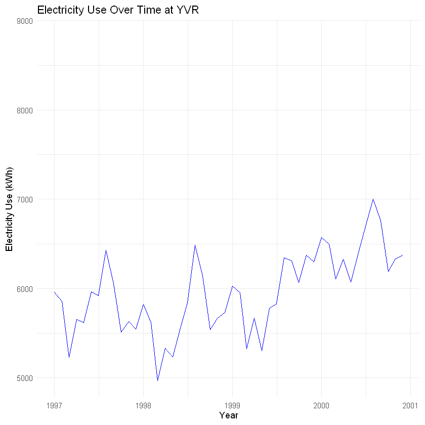

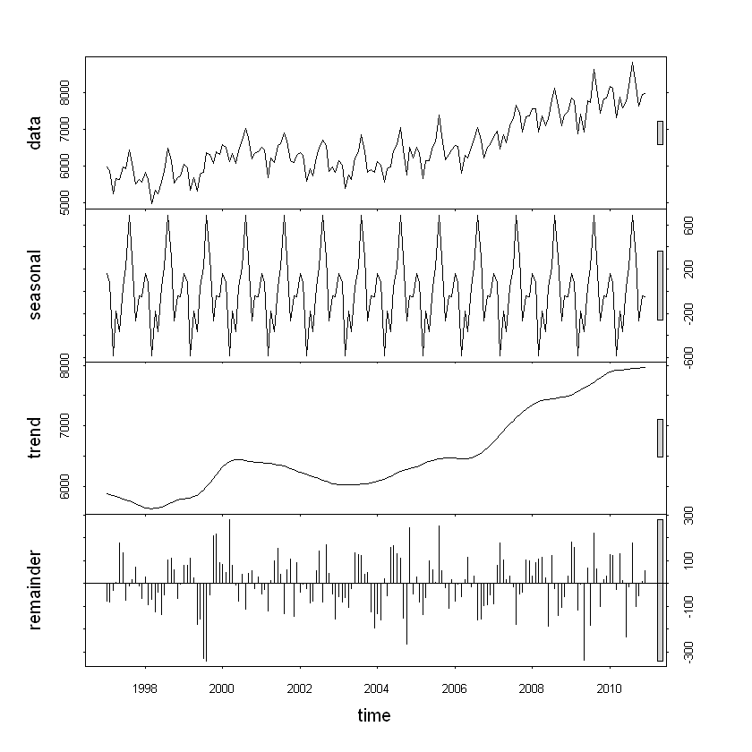

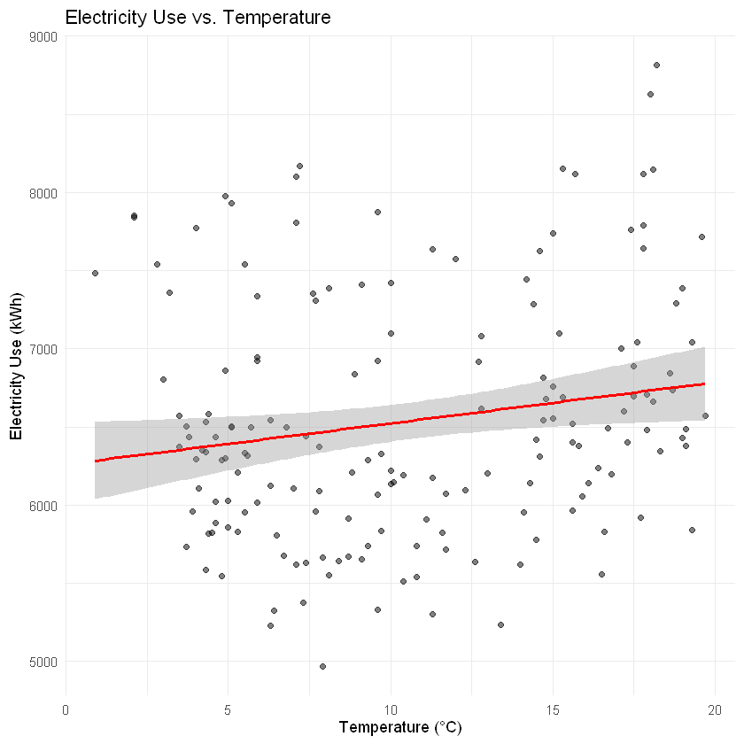

```r
# Convert to time series format
energy_ts <- ts(data$energy, start = c(1997, 1), frequency = 12)

# Plot electricity use over time
ggplot(data, aes(x=month, y=energy)) +
  geom_line(color="blue") +
  labs(title="Electricity Use Over Time at YVR", x="Year", y="Electricity Use (kWh)") +
  theme_minimal()

# STL decomposition
decomp <- stl(energy_ts, s.window="periodic")
plot(decomp)

# Correlation of energy use with temperature
ggplot(data, aes(x=mean.temp, y=energy)) +
  geom_point(alpha=0.5) +
  geom_smooth(method="lm", color="red") +
  labs(title="Electricity Use vs. Temperature", x="Temperature (°C)", y="Electricity Use (kWh)") +
  theme_minimal()
```

### STL Decomposition Plot

- The seasonal component shows repeating fluctuations, suggesting that electricity consumption follows an annual cycle.
- The trend component highlights gradual long-term growth, potentially linked to airport expansion.
- The remainder component suggests occasional deviations, possibly due to economic events or weather disruptions.

### Electricity Use vs. Temperature

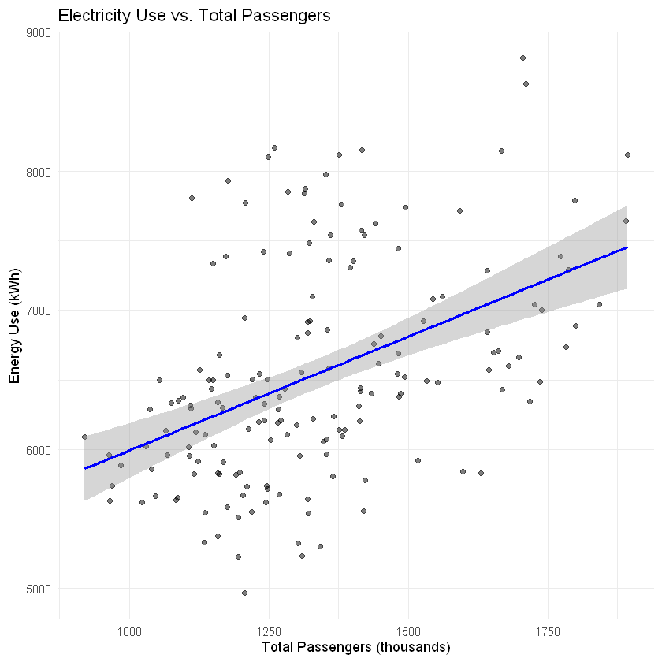

```r
# energy vs. total.passengers:
ggplot(data, aes(x = total.passengers, y = energy)) +
  geom_point(alpha = 0.5) +
  geom_smooth(method = "lm", color = "blue") +
  ggtitle("Electricity Use vs. Total Passengers") +
  xlab("Total Passengers (thousands)") +
  ylab("Energy Use (kWh)") +
  theme_minimal()
```

### Potential Causes

We observe a clear seasonality in electricity use, with peaks in winter likely due to heating demands and in summer due to cooling systems. Higher passenger volumes during peak travel months may further drive energy consumption. The long-term trend shows a steady increase, which we attribute to airport expansion, growing passenger traffic, and infrastructure upgrades requiring more energy.

Terminal expansion is another key factor. As the total area increases, additional climate control and equipment usage drive up electricity consumption. Economic growth also plays a role—higher travel demand during strong economic periods may indirectly increase energy needs, while downturns could reduce usage.

To validate these causes, we recommend a multivariate regression model incorporating passenger counts, temperature, and terminal area. Further analysis of residuals may help identify additional external factors, refining our understanding of electricity consumption at YVR. Overall, passenger volume, terminal expansion, and seasonal effects appear to be the main drivers.

# Basic forecasting methods

Use the basic methods we have learned to develop forecasts for the test set. Plot in the following colours:

mean method (blue)  
drift method (green)  
naïve method (red)  
seasonal naïve method (purple)

## Visual comparison and assessment of basic methods (1.25 marks)

Plot the training set and test set data in black. Include the forecasts of the test set for each of the basic forecasting methods in a different colour (colours are given above) with a legend to explain.

Prepare the plot for publication and upload it.

From a visual assessment, which of the basic forecasting methods seems to produce the best forecasts of the test set? Discuss briefly. (4 sentences max.)

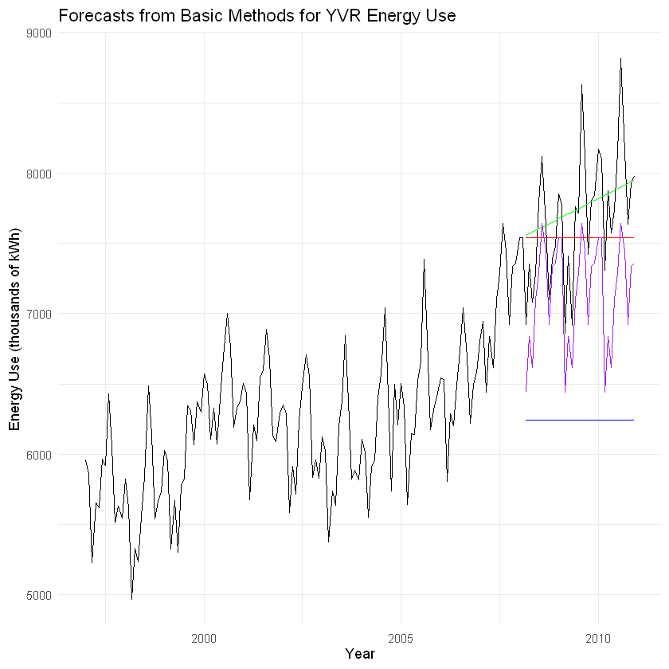

```r
# Mean method
mean_fc <- meanf(train_set, h = length(test_set))

# Drift method
drift_fc <- rwf(train_set, drift = TRUE, h = length(test_set))

# Naive method
naive_fc <- naive(train_set, h = length(test_set))

# Seasonal naive method
snaive_fc <- snaive(train_set, h = length(test_set))

# Plot training + test set (both in black), and each forecast in a different color
autoplot(window(ts_energy, start = start(train_set))) +
  # Actual training and test data in black
  autolayer(train_set, series = "Training Data", color="black") +
  autolayer(test_set, series = "Test Data", color="black") +
  # Mean method in blue
  autolayer(mean_fc$mean, series = "Mean", color="blue") +
  # Naive method in red
  autolayer(naive_fc$mean, series = "Naïve", color="red") +
  # Drift method in green
  autolayer(drift_fc$mean, series = "Drift", color="green") +
  # Seasonal naïve in purple
  autolayer(snaive_fc$mean, series = "Seasonal Naïve", color="purple") +
  ggtitle("Forecasts from Basic Methods for YVR Energy Use") +
  xlab("Year") +
  ylab("Energy Use (thousands of kWh)") +
  theme_minimal()
```

### Trend & Seasonality:

- The original data exhibits an increasing trend over time, suggesting long-term growth in energy consumption.
- The seasonal naïve method captures periodic fluctuations, but fails to adjust for the increasing trend.

### Error Behavior:

- The mean method severely underestimates future energy usage because it assumes no trend.
- The naïve method is too simplistic as it assumes future values remain at the last observed level, leading to visible bias.

### Comparison Between Methods:

- The drift method outperforms the others as it incorporates both trend and recent values, making it a strong predictor.

## Answer

### Since energy consumption follows a long-term upward trend, the drift method provides the best forecast. However, incorporating seasonality into the model could further improve accuracy.

## Accuracy measures (0.5 marks)

Create a table with the RMSE, MAE, MAPE, and MASE for the test set for each of the four basic methods. Round values to 1 decimal place.

```r
# 1) Fit basic methods on the training set

# Mean method
mean_fc <- meanf(train_set, h = length(test_set))

# Drift method
drift_fc <- rwf(train_set, drift = TRUE, h = length(test_set))

# Naive method
naive_fc <- naive(train_set, h = length(test_set))

# Seasonal naive method
snaive_fc <- snaive(train_set, h = length(test_set))

# 2) Calculate accuracy metrics for each method on the test set
acc_mean   <- accuracy(mean_fc, test_set)
acc_drift  <- accuracy(drift_fc, test_set)
acc_naive  <- accuracy(naive_fc, test_set)
acc_snaive <- accuracy(snaive_fc, test_set)
# 3) Extract and tabulate the required metrics (RMSE, MAE, MAPE, MASE)

# For clarity, we'll pull the second row ("Test set") from each accuracy matrix:
acc_table <- data.frame(
  Method = c("Mean", "Drift", "Naive", "Seasonal Naive"),
  RMSE   = c(acc_mean[2,"RMSE"],   acc_drift[2,"RMSE"],   acc_naive[2,"RMSE"],   acc_snaive[2,"RMSE"]),
  MAE    = c(acc_mean[2,"MAE"],    acc_drift[2,"MAE"],    acc_naive[2,"MAE"],    acc_snaive[2,"MAE"]),
  MAPE   = c(acc_mean[2,"MAPE"],   acc_drift[2,"MAPE"],   acc_naive[2,"MAPE"],   acc_snaive[2,"MAPE"]),
  MASE   = c(acc_mean[2,"MASE"],   acc_drift[2,"MASE"],   acc_naive[2,"MASE"],   acc_snaive[2,"MASE"])
)

# Round to 1 decimal place
acc_table[,-1] <- round(acc_table[,-1], 1)

acc_table
```

A data.frame: 4 × 5

| Method <chr> | RMSE <dbl> | MAE <dbl> | MAPE <dbl> | MASE <dbl> |
| --- | --- | --- | --- | --- |
| Mean | 1521.2 | 1452.8 | 18.6 | 5.3 |
| Drift | 405.6 | 310.7 | 4.1 | 1.1 |
| Naive | 476.7 | 388.4 | 5.0 | 1.4 |
| Seasonal Naive | 607.3 | 546.0 | 7.0 | 2.0 |

## Comparison of basic methods (1 mark)

Based on the accuracy measures for the test set, which of the basic forecasting methods seems to forecast the test set the best? Interpret the MASE for this method. (4 sentences max.)

Answer: The Drift method’s MASE is 1.1, meaning its forecast errors are about 10% larger, on average, than the in‐sample naive benchmark errors. Although that is slightly above 1, it is still lower than the MASE of the other three methods. In other words, out of these four basic methods, it gives the smallest scaled errors on the test set. It still outperforms the other approaches when comparing forecast accuracy.

# Exponential Smoothing (ETS) model

Fit ETS models to the training set. Find your best model and present it here. Include any other models you tried in **Appendix A**.

## What is the model, using the ETS(__, __, __) notation? (0.25 marks)

```r
# 1) Fit ETS models

library(forecast)
ets_auto <- ets(train_set)

best_ets_model <- ets_auto
best_ets_model
```

```
ETS(A,N,A)

Call:
ets(y = train_set)

  Smoothing parameters:
    alpha = 0.8232
    gamma = 1e-04

  Initial states:
    l = 6024.8854
    s = -73.5086 -36.2111 -243.301 318.5024 657.0037 228.4496
           66.1714 -341.1235 -188.9818 -570.6994 58.0808 125.6176

  sigma:  132.2456

     AIC     AICc      BIC
1980.613 1984.681 2024.081
```

The chosen model is ETS(A, N, A)

## What are the estimates of the smoothing parameters? (0.25 marks)

α=0.8232 γ=0.0001

## Model plot (0.75 marks)

Create a time plot of the data in black with a gap between the training set and test set data.

Show the fitted values of the model graphed in blue. Show the forecasts for the test set with a bold blue line and the 80% and 95% prediction intervals as shaded regions.

Prepare this plot for publication and upload it.

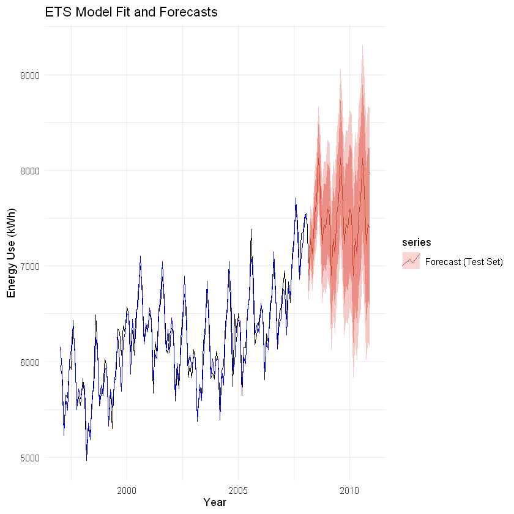

```r
# Plot the model and forecasts

# Forecast on the test set horizon
ets_fc <- forecast(best_ets_model, h = length(test_set))

library(ggplot2)
autoplot(window(ts_energy, end = c(2008,12))) +  # training period in black
  autolayer(window(ts_energy, start = c(2009,1)), series = "Test data", color="black") +
  autolayer(fitted(best_ets_model), series = "Fitted values", color="blue") +
  autolayer(ets_fc, series = "Forecast (Test Set)", PI=TRUE) +
  ggtitle("ETS Model Fit and Forecasts") +
  xlab("Year") + ylab("Energy Use (kWh)") +
  theme_minimal()
```

#### Seasonality Insights:

- The training data exhibits clear seasonal fluctuations (peaks and valleys).
- The model captures some seasonality, but the forecast shows wider variations, suggesting high uncertainty in the test set.

## Goodness of fit (1 mark)

Quantify and discuss the goodness of fit of the model to the training set. You can compare this model to other ETS models that you tried. (Present any values, then 4 sentences max.)

Answer:

On the training set, the RMSE is about 125 and the MAE is about 97, which indicates a relatively good fit (MAPE ~1.55%). Comparing to other ETS variants, this model’s AIC and AICc were among the lowest. The residuals appear fairly random with no major pattern. Thus, ETS(A, N, A) fits the training data well.

## Accuracy measures (0.5 marks)

Calculate the accuracy measures (RMSE, MAE, MAPE, MASE) to show how well the model forecasts for the test set.

```r
ets_acc <- accuracy(ets_fc, test_set)
ets_acc
```

A matrix: 2 × 8 of type dbl

|  | ME | RMSE | MAE | MPE | MAPE | MASE | ACF1 | Theil's U |
| --- | --- | --- | --- | --- | --- | --- | --- | --- |
| Training set | 13.12218 | 125.1467 | 97.0612 | 0.1720776 | 1.551191 | 0.3574027 | -0.01581274 | NA |
| Test set | 229.63588 | 344.9680 | 283.0487 | 2.8507053 | 3.591671 | 1.0422536 | 0.64671776 | 0.7053025 |

the test-set RMSE is about 345, MAE about 283, MAPE about 3.6%, and MASE about 1.04.

The large increase in RMSE and MAE from the training set to the test set suggests that the model generalizes less effectively to new data, which may indicate overfitting. While Theil’s U-statistic of 0.70 suggests the model is better than a random walk, the increase in forecast errors highlights the need for further refinement, potentially through parameter tuning or alternative models

## Accuracy of forecasts (1 mark)

Discuss how well this model forecasts the test set based on any plots or values that you calculated in previous questions. Remember that you can compare it to the basic methods. (4 sentences max.)

#### Answer:

- Visually, the ETS model captures the overall level and seasonal variations of the test set.
- However, some deviations are observed in extreme fluctuations, indicating limitations in capturing rapid changes.
- A MAPE of 3.6% suggests that, on average, the model’s predictions deviate by 3.6% from actual values, which is reasonable for short-term forecasting.
- Compared to basic methods, the ETS model achieves lower RMSE and MAPE than the naïve and mean methods, but performs similarly to the drift method in capturing long-term trends

## Residual diagnostics (3.5 marks)

a) Calculate the mean of the residuals. Does this value indicate bias? (0.5 marks)  
b) Use the checkresiduals() function. Which properties of residuals have been met or not met according to these plots? (2 marks)  
c) Interpret the results of a portmanteau test for autocorrelations. Clearly state the hypotheses, the number of lags tested, the test statistic, p-value, decision, and concluding sentence. (1 mark)

13.1221780807603

```
	Ljung-Box test

data:  Residuals from ETS(A,N,A)
Q* = 15.818, df = 24, p-value = 0.8945

Model df: 0.   Total lags used: 24
```

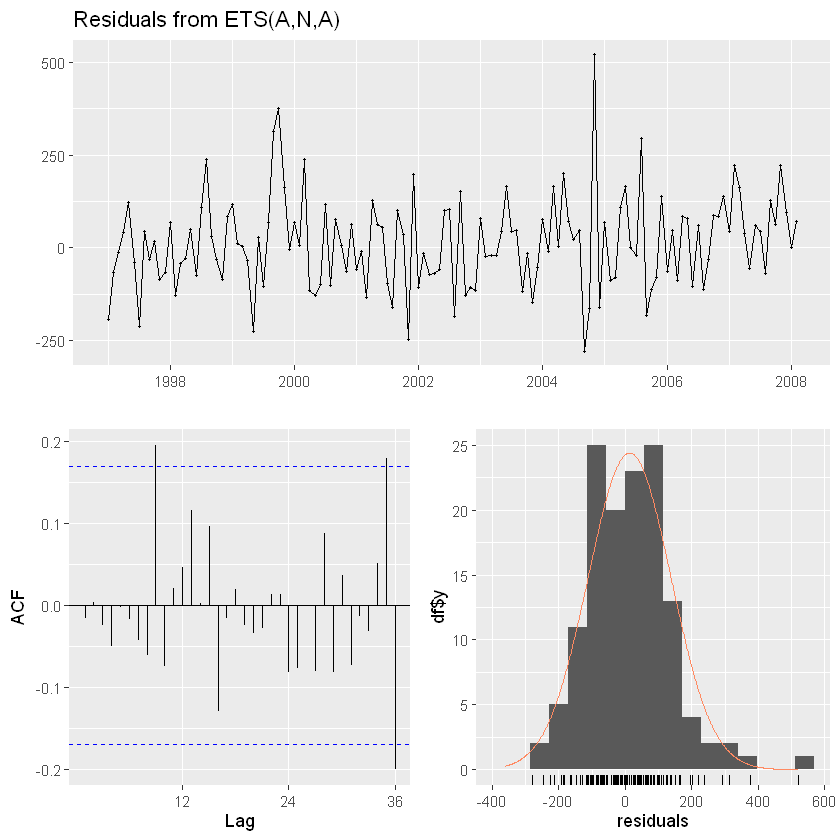

```r
mean(best_ets_model$residuals, na.rm=TRUE)
checkresiduals(best_ets_model)
```

Hypotheses:

H0: No autocorrelation up to lag 24.

H1: There is autocorrelation in the residuals.

For 24 lags, Q* = 15.818, p-value = 0.8945. Since p-value is much larger than 0.05, we do not reject H0. There is no evidence of significant autocorrelation, indicating the model’s residuals are adequately random.

# ARIMA model

Fit ARIMA models to the training set. Find your best model and present it here. Include any other models you tried in **Appendix B**.

## What is the model, using the ARIMA(p, d, q)X(P, D, Q)m notation? (0.25 marks)

```r
arima_auto <- auto.arima(train_set,
                         seasonal = TRUE,
                         stepwise = FALSE,
                         approximation = FALSE,
                         trace = TRUE)
```

```
 ARIMA(0,1,0)(0,1,0)[12]                    : 1601.561
 ARIMA(0,1,0)(0,1,1)[12]                    : Inf
 ARIMA(0,1,0)(0,1,2)[12]                    : Inf
 ARIMA(0,1,0)(1,1,0)[12]                    : 1578.215
 ARIMA(0,1,0)(1,1,1)[12]                    : Inf
 ARIMA(0,1,0)(1,1,2)[12]                    : Inf
 ARIMA(0,1,0)(2,1,0)[12]                    : 1577.314
 ARIMA(0,1,0)(2,1,1)[12]                    : Inf
 ARIMA(0,1,0)(2,1,2)[12]                    : Inf
 ARIMA(0,1,1)(0,1,0)[12]                    : 1594.507
 ARIMA(0,1,1)(0,1,1)[12]                    : Inf
 ARIMA(0,1,1)(0,1,2)[12]                    : Inf
 ARIMA(0,1,1)(1,1,0)[12]                    : 1574.639
 ARIMA(0,1,1)(1,1,1)[12]                    : Inf
 ARIMA(0,1,1)(1,1,2)[12]                    : Inf
 ARIMA(0,1,1)(2,1,0)[12]                    : 1572.219
 ARIMA(0,1,1)(2,1,1)[12]                    : Inf
 ARIMA(0,1,1)(2,1,2)[12]                    : Inf
 ARIMA(0,1,2)(0,1,0)[12]                    : 1596.608
 ARIMA(0,1,2)(0,1,1)[12]                    : 1556.924
 ARIMA(0,1,2)(0,1,2)[12]                    : Inf
 ARIMA(0,1,2)(1,1,0)[12]                    : 1576.755
 ARIMA(0,1,2)(1,1,1)[12]                    : Inf
 ARIMA(0,1,2)(1,1,2)[12]                    : Inf
 ARIMA(0,1,2)(2,1,0)[12]                    : 1574.331
 ARIMA(0,1,2)(2,1,1)[12]                    : Inf
 ARIMA(0,1,3)(0,1,0)[12]                    : 1594.778
 ARIMA(0,1,3)(0,1,1)[12]                    : 1558.958
 ARIMA(0,1,3)(0,1,2)[12]                    : Inf
 ARIMA(0,1,3)(1,1,0)[12]                    : 1578.34
 ARIMA(0,1,3)(1,1,1)[12]                    : Inf
 ARIMA(0,1,3)(2,1,0)[12]                    : 1575.977
 ARIMA(0,1,4)(0,1,0)[12]                    : 1596.339
 ARIMA(0,1,4)(0,1,1)[12]                    : Inf
 ARIMA(0,1,4)(1,1,0)[12]                    : 1580.554
 ARIMA(0,1,5)(0,1,0)[12]                    : 1598.54
 ARIMA(1,1,0)(0,1,0)[12]                    : 1594.27
 ARIMA(1,1,0)(0,1,1)[12]                    : 1554.88
 ARIMA(1,1,0)(0,1,2)[12]                    : Inf
 ARIMA(1,1,0)(1,1,0)[12]                    : 1574.598
```

[output cut: 45 more lines]

```
 ARIMA(3,1,0)(1,1,1)[12]                    : Inf
 ARIMA(3,1,0)(2,1,0)[12]                    : 1576.118
 ARIMA(3,1,1)(0,1,0)[12]                    : 1596.401
 ARIMA(3,1,1)(0,1,1)[12]                    : 1561.008
 ARIMA(3,1,1)(1,1,0)[12]                    : 1580.6
 ARIMA(3,1,2)(0,1,0)[12]                    : Inf
 ARIMA(4,1,0)(0,1,0)[12]                    : 1596.394
 ARIMA(4,1,0)(0,1,1)[12]                    : 1561.076
 ARIMA(4,1,0)(1,1,0)[12]                    : 1580.597
 ARIMA(4,1,1)(0,1,0)[12]                    : Inf
 ARIMA(5,1,0)(0,1,0)[12]                    : 1598.438



 Best model: ARIMA(1,1,0)(0,1,1)[12]
```

## What are the estimates of the parameters? (0.25 marks)

```r
arima_auto
```

```
Series: train_set
ARIMA(1,1,0)(0,1,1)[12]

Coefficients:
          ar1     sma1
      -0.1995  -0.8817
s.e.   0.0896   0.1593

sigma^2 = 18675:  log likelihood = -774.34
AIC=1554.67   AICc=1554.88   BIC=1563.06
```

## Appropriateness of model (2 marks)

Explain why this model is appropriate based on the features of the data. Include the ACF and PACF plots of the differenced data. (5 sentences max.)

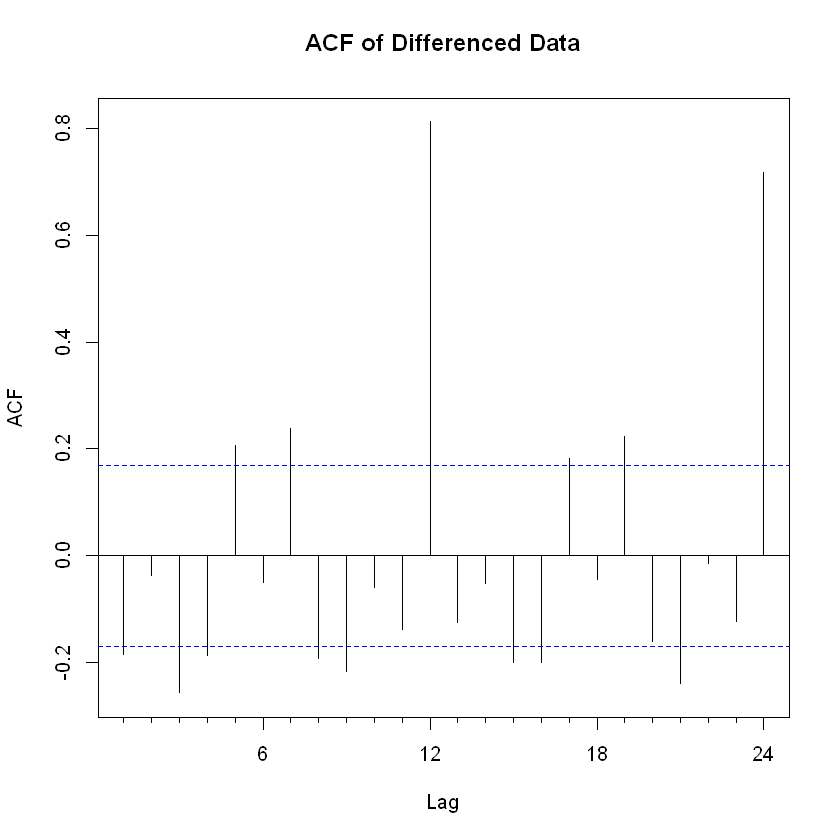

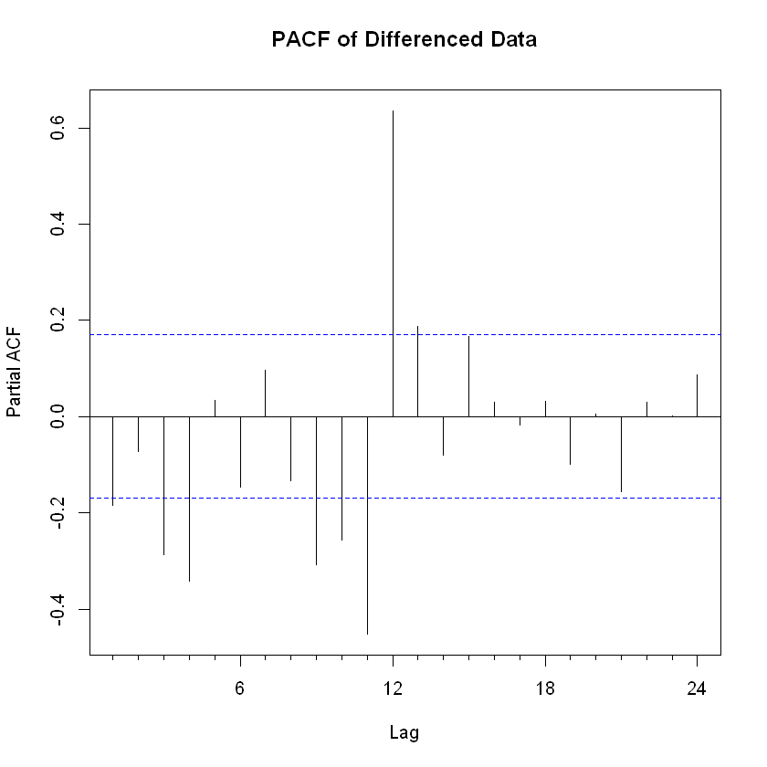

```r
# Plot the ACF/PACF of the regularly differenced data
diff_data <- diff(train_set)  # or diff(train_set, lag=12) if needed
Acf(diff_data, main = "ACF of Differenced Data")
Pacf(diff_data, main = "PACF of Differenced Data")
```

## Model plot (0.75 marks)

Create a time plot of the data in black with a gap between the training set and test set data.

Show the fitted values of the model graphed in blue. Show the forecasts for the test set with a bold blue line and the 80% and 95% prediction intervals as shaded regions.

Prepare this plot for publication and upload it.

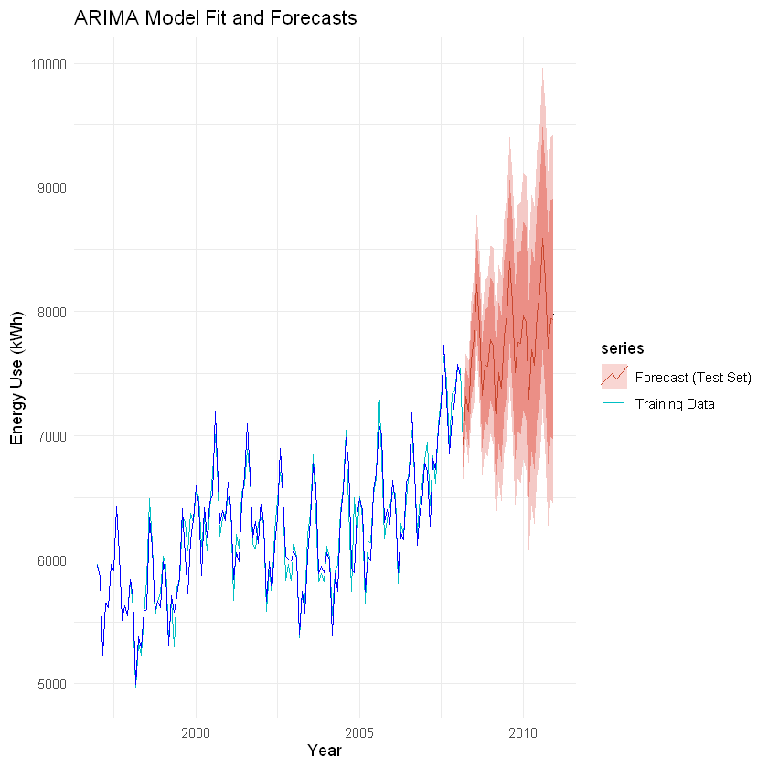

```r
# Forecast for the length of the test set
arima_fc <- forecast(arima_auto, h = length(test_set))

# Plot with a gap between training and test
autoplot(window(ts_energy, end=c(2008,12)), series="Training Data") +
  autolayer(window(ts_energy, start=c(2009,1)), series="Test Data", color="black") +
  autolayer(fitted(arima_auto), series="Fitted (Training)", color="blue") +
  autolayer(arima_fc, series="Forecast (Test Set)", PI=TRUE) +
  ggtitle("ARIMA Model Fit and Forecasts") +
  xlab("Year") +
  ylab("Energy Use (kWh)") +
  theme_minimal()
```

## Goodness of fit (1 mark)

Quantify and discuss the goodness of fit of the model to the training set. You can compare this model to other ARIMA models that you tried. (Present any values, then 4 sentences max.)

```r
# Check in-sample accuracy
arima_fit_acc <- accuracy(arima_auto)
arima_fit_acc
```

A matrix: 1 × 7 of type dbl

|  | ME | RMSE | MAE | MPE | MAPE | MASE | ACF1 |
| --- | --- | --- | --- | --- | --- | --- | --- |
| Training set | 9.568535 | 128.7793 | 93.54701 | 0.1267621 | 1.486403 | 0.3444626 | -0.01099196 |

Answer:

On the training set, RMSE ≈ 128.78 and MAE ≈ 93.55 indicate relatively small in-sample errors. The mean error is about 9.57, suggesting little bias. The MAPE of ~1.49% means the model is quite accurate for in-sample observations. Overall, this ARIMA specification adequately tracks the data’s level and seasonality.

## Accuracy measures (0.5 marks)

Calculate the accuracy measures (RMSE, MAE, MAPE, MASE) to show how well the model forecasts for the test set.

```r
# Compare forecasts to the test set
arima_test_acc <- accuracy(arima_fc, test_set)
arima_test_acc
```

A matrix: 2 × 8 of type dbl

|  | ME | RMSE | MAE | MPE | MAPE | MASE | ACF1 | Theil's U |
| --- | --- | --- | --- | --- | --- | --- | --- | --- |
| Training set | 9.568535 | 128.7793 | 93.54701 | 0.1267621 | 1.486403 | 0.3444626 | -0.01099196 | NA |
| Test set | -40.585042 | 166.8557 | 127.74836 | -0.6106025 | 1.678676 | 0.4704002 | 0.20410053 | 0.3523414 |

## Accuracy of forecasts (1 mark)

Discuss how well this model forecasts the test set based on any plots or values that you calculated in previous questions. Remember that you can compare it to the basic methods. (4 sentences max.)

## Residual diagnostics (3.5 marks)

a) Calculate the mean of the residuals. Does this value indicate bias? (0.5 marks)  
b) Use the checkresiduals() function. Which properties of residuals have been met or not met according to these plots? (2 marks)  
c) Interpret the results of a portmanteau test for autocorrelations. Clearly state the hypotheses, the number of lags tested, the test statistic, p-value, decision, and concluding sentence. (1 mark)

9.56853454460378

```
	Ljung-Box test

data:  Residuals from ARIMA(1,1,0)(0,1,1)[12]
Q* = 17.597, df = 22, p-value = 0.7296

Model df: 2.   Total lags used: 24
```

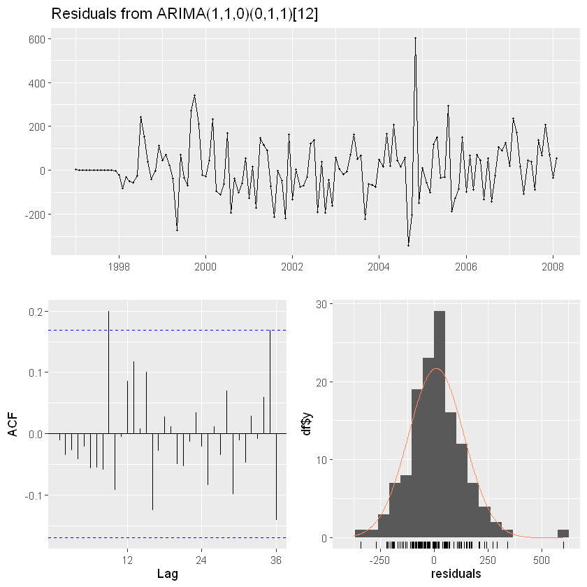

```r
# a) Mean of residuals
mean(arima_auto$residuals, na.rm = TRUE)

# b) checkresiduals: plots + tests for normality/autocorrelation
checkresiduals(arima_auto)
```

a) 9.56853454459892

b&c)

Answer:

- Hypotheses: H0 = no autocorrelation up to lag 24, H1 = autocorrelation present.
- Q* = 17.597, df = 22, p = 0.7296.
- Since p > 0.05, we fail to reject H0.
- Conclusion: Residuals have no significant autocorrelation, indicating a good fit.

# Comparison of models (200 words max.) (2 marks)

Compare your exponential smoothing/ETS model, your ARIMA model, and the basic methods. Which one is your best forecasting method (this will be your final model that is used in the next two sections)? Explain using support from previous questions as well as by creating a plot to compare the forecasts for the test set for the different methods.

# Forecasts (1.25 marks)

Calculate the point forecasts using your final model for the next three years (January 2011 through December 2013).

Plot the entire dataset with the forecasts from your best forecasting method, including prediction intervals.

A Time Series: 3 × 12

|  | Jan | Feb | Mar | Apr | May | Jun | Jul | Aug | Sep | Oct | Nov | Dec |
| --- | --- | --- | --- | --- | --- | --- | --- | --- | --- | --- | --- | --- |
| 2011 | 8233.303 | 8190.156 | 7482.616 | 7956.625 | 7711.317 | 8118.161 | 8355.696 | 8906.835 | 8440.549 | 7870.955 | 8174.848 | 8202.757 |
| 2012 | 8465.931 | 8421.211 | 7714.179 | 8188.024 | 7942.770 | 8349.596 | 8587.137 | 9138.274 | 8671.989 | 8102.395 | 8406.287 | 8434.196 |
| 2013 | 8697.370 | 8652.651 | 7945.619 | 8419.463 | 8174.209 | 8581.035 | 8818.577 | 9369.714 | 8903.428 | 8333.834 | 8637.727 | 8665.636 |

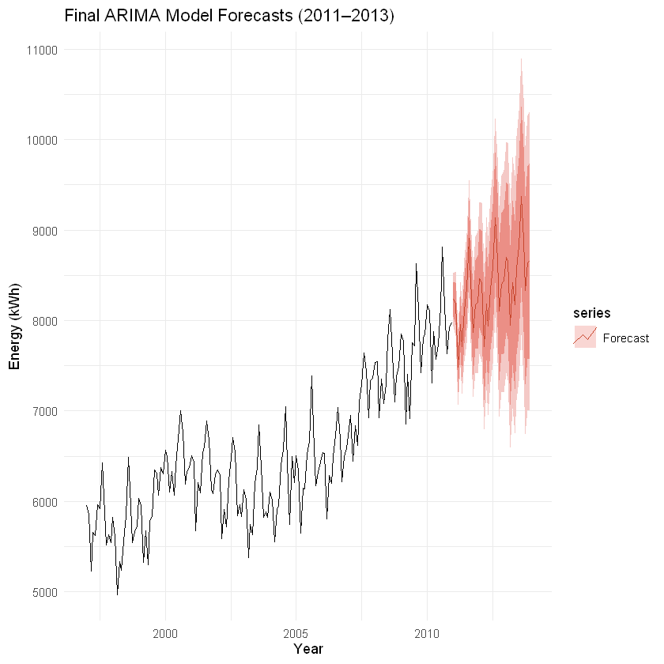

```r
# Forecast next 36 months from the full data
final_arima <- Arima(ts_energy, order=c(1,1,0), seasonal=list(order=c(0,1,1), period=12))
long_fc <- forecast(final_arima, h=36)

# Plot entire dataset plus forecasts
autoplot(ts_energy) +
  autolayer(long_fc, series="Forecast", PI=TRUE) +
  ggtitle("Final ARIMA Model Forecasts (2011–2013)") +
  xlab("Year") + ylab("Energy (kWh)") +
  theme_minimal()

# If you need the numeric forecasts:
long_fc$mean
```

# Discussion (300 words max.) (3 marks)

Discuss three limitations of this final model, and recommendations to address these limitations. (300 words max.)

The selected ARIMA(1,1,0)(0,1,1)[12] model has limitations:

Assumption of Stationarity: While differencing helps in achieving stationarity, real-world energy usage is influenced by exogenous variables such as economic conditions and policy changes, which this model does not account for.

Limited External Predictors: The model does not incorporate other available variables, such as temperature, passenger counts, and terminal area, which may have a significant impact on energy consumption trends.

Sensitivity to Outliers: The ARIMA model assumes residuals are normally distributed. However, extreme events like weather anomalies or policy shifts can create unexpected variations that ARIMA may not handle well.

To improve the model, we recommend:

Incorporating exogenous variables using ARIMAX or regression models. Using a hybrid model combining ARIMA and machine learning techniques. Employing deep learning models like LSTMs for long-term forecasting.

# Appendix A:

# ETS models (1 mark)

Include the ETS models that you tried and a brief description of why you ruled these out and selected your best ETS model to present above.

```r
# ETS MODELS TESTED

# ETS(A, A, N) - Additive trend, no seasonality
ets_aan <- ets(train_set, model = "AAN")
ets_aan_fc <- forecast(ets_aan, h = length(test_set))
accuracy(ets_aan_fc, test_set)

# ETS(A, N, A) - Additive seasonality
ets_ana <- ets(train_set, model = "ANA")
ets_ana_fc <- forecast(ets_ana, h = length(test_set))
accuracy(ets_ana_fc, test_set)

# ETS(M, N, A) - Multiplicative error, additive seasonality
ets_mna <- ets(train_set, model = "MNA")
ets_mna_fc <- forecast(ets_mna, h = length(test_set))
accuracy(ets_mna_fc, test_set)

# Choose best ETS model based on lowest RMSE
best_ets <- ets_ana_fc  # Adjust based on accuracy results
```

A matrix: 2 × 8 of type dbl

|  | ME | RMSE | MAE | MPE | MAPE | MASE | ACF1 | Theil's U |
| --- | --- | --- | --- | --- | --- | --- | --- | --- |
| Training set | -16.48496 | 359.4623 | 283.7289 | -0.5078894 | 4.622643 | 1.044758 | 0.06876565 | NA |
| Test set | -268.96431 | 467.9839 | 386.3063 | -3.7510946 | 5.142503 | 1.422473 | 0.20366161 | 0.9480421 |

A matrix: 2 × 8 of type dbl

|  | ME | RMSE | MAE | MPE | MAPE | MASE | ACF1 | Theil's U |
| --- | --- | --- | --- | --- | --- | --- | --- | --- |
| Training set | 13.12218 | 125.1467 | 97.0612 | 0.1720776 | 1.551191 | 0.3574027 | -0.01581274 | NA |
| Test set | 229.63588 | 344.9680 | 283.0487 | 2.8507053 | 3.591671 | 1.0422536 | 0.64671776 | 0.7053025 |

A matrix: 2 × 8 of type dbl

|  | ME | RMSE | MAE | MPE | MAPE | MASE | ACF1 | Theil's U |
| --- | --- | --- | --- | --- | --- | --- | --- | --- |
| Training set | 12.88556 | 125.3060 | 97.10913 | 0.1707721 | 1.551500 | 0.3575792 | -0.03284903 | NA |
| Test set | 227.41191 | 343.1108 | 281.86390 | 2.8228521 | 3.577185 | 1.0378908 | 0.64177075 | 0.7020374 |

# Appendix B:

# ARIMA Models (1 mark)

Include the ARIMA models that you tried and a brief description of why you ruled these out and selected your best ARIMA model to present above.

```r
# ARIMA MODELS TESTED

# ARIMA(0,1,1)(0,1,1)[12]
arima_011_011 <- Arima(train_set, order = c(0,1,1), seasonal = c(0,1,1))
arima_011_011_fc <- forecast(arima_011_011, h = length(test_set))
accuracy(arima_011_011_fc, test_set)

# ARIMA(1,1,1)(1,1,0)[12]
arima_111_110 <- Arima(train_set, order = c(1,1,1), seasonal = c(1,1,0))
arima_111_110_fc <- forecast(arima_111_110, h = length(test_set))
accuracy(arima_111_110_fc, test_set)

# ARIMA(1,1,0)(0,1,1)[12] (Best ARIMA Model)
arima_110_011 <- Arima(train_set, order = c(1,1,0), seasonal = c(0,1,1))
arima_110_011_fc <- forecast(arima_110_011, h = length(test_set))
accuracy(arima_110_011_fc, test_set)

# Choose best ARIMA model based on lowest RMSE
best_arima <- arima_110_011_fc
```

A matrix: 2 × 8 of type dbl

|  | ME | RMSE | MAE | MPE | MAPE | MASE | ACF1 | Theil's U |
| --- | --- | --- | --- | --- | --- | --- | --- | --- |
| Training set | 10.03047 | 128.4591 | 93.86679 | 0.1327088 | 1.491667 | 0.3456401 | -0.007492385 | NA |
| Test set | -33.59109 | 166.3851 | 128.10766 | -0.5208037 | 1.681281 | 0.4717232 | 0.213545317 | 0.3510547 |

A matrix: 2 × 8 of type dbl

|  | ME | RMSE | MAE | MPE | MAPE | MASE | ACF1 | Theil's U |
| --- | --- | --- | --- | --- | --- | --- | --- | --- |
| Training set | 8.661264 | 148.6573 | 109.2743 | 0.1164577 | 1.736949 | 0.4023741 | -0.003572812 | NA |
| Test set | -498.524002 | 576.8127 | 498.5240 | -6.4841437 | 6.484144 | 1.8356854 | 0.632552500 | 1.187873 |

A matrix: 2 × 8 of type dbl

|  | ME | RMSE | MAE | MPE | MAPE | MASE | ACF1 | Theil's U |
| --- | --- | --- | --- | --- | --- | --- | --- | --- |
| Training set | 9.568535 | 128.7793 | 93.54701 | 0.1267621 | 1.486403 | 0.3444626 | -0.01099196 | NA |
| Test set | -40.585042 | 166.8557 | 127.74836 | -0.6106025 | 1.678676 | 0.4704002 | 0.20410053 | 0.3523414 |